# Predicting_Fuel_efficiency_using_Python_and_Tensorflow

```python
!pip install -q seaborn
```

```python
import matplotlib.pyplot as plt
import numpy as np
import pandas as pd
import seaborn as sns
import tensorflow as tf

from tensorflow import keras
from tensorflow.keras import layers
```

```python
np.set_printoptions(precision=3, suppress=True)
```

The AutoMPG dataset: We will first download and then import the dataset using pandas

```python
#The url containing our dataset
url = 'http://archive.ics.uci.edu/ml/machine-learning-databases/auto-mpg/auto-mpg.data'

#The Column names we want to read
column_names = ['MPG', 'Cylinders', 'Displacement', 'Horsepower', 'Weight',
                'Acceleration', 'Model Year', 'Origin']

raw_dataset = pd.read_csv(url, names=column_names,
                          na_values='?', comment='\t',
                          sep=' ', skipinitialspace=True)
```

```python
#copy the raw_dataset and store it in a different variable
dataset = raw_dataset.copy()
dataset.tail()

#The dataset.tail() should display is table of values
```

|  | MPG | Cylinders | Displacement | Horsepower | Weight | Acceleration | Model Year | Origin |
| --- | --- | --- | --- | --- | --- | --- | --- | --- |
| 393 | 27.0 | 4 | 140.0 | 86.0 | 2790.0 | 15.6 | 82 | 1 |
| 394 | 44.0 | 4 | 97.0 | 52.0 | 2130.0 | 24.6 | 82 | 2 |
| 395 | 32.0 | 4 | 135.0 | 84.0 | 2295.0 | 11.6 | 82 | 1 |
| 396 | 28.0 | 4 | 120.0 | 79.0 | 2625.0 | 18.6 | 82 | 1 |
| 397 | 31.0 | 4 | 119.0 | 82.0 | 2720.0 | 19.4 | 82 | 1 |

```python
#Its time to clean the data
#check if the dataset has any unknown values/ null values
dataset.isna().sum()
```

|  | 0 |
| --- | --- |
| MPG | 0 |
| Cylinders | 0 |
| Displacement | 0 |
| Horsepower | 6 |
| Weight | 0 |
| Acceleration | 0 |
| Model Year | 0 |
| Origin | 0 |

**dtype:** int64

```python
#We can see that the Horsepower data contains 6 null values, we will drop those values/rows
dataset = dataset.dropna()
```

```python
#check to see if the rows that are null have been dropped
dataset.isna().sum()
```

|  | 0 |
| --- | --- |
| MPG | 0 |
| Cylinders | 0 |
| Displacement | 0 |
| Horsepower | 0 |
| Weight | 0 |
| Acceleration | 0 |
| Model Year | 0 |
| Origin | 0 |

**dtype:** int64

```python
#They have been dropped!. This makes manipulating the data a whole lot easier
```

When creating a prediction model, we would like all our data/ rows to be numerical. The orgin row is categorical instead of numerical so the next step is to turn the categorical data to numeric data. This process is known as "One-hot encoding" and we can easily do this by using the pandas library by utilizing the *pd.get_dummies* function

```python
#First, we'll map the countries to the Origin row of the dataset
dataset['Origin'] = dataset['Origin'].map({1: 'USA', 2: 'Europe', 3: 'Japan'})
```

```python
dataset = pd.get_dummies(dataset, columns= ['Origin'], prefix = '', prefix_sep = '')
dataset.tail()
```

|  | MPG | Cylinders | Displacement | Horsepower | Weight | Acceleration | Model Year | Europe | Japan | USA |
| --- | --- | --- | --- | --- | --- | --- | --- | --- | --- | --- |
| 393 | 27.0 | 4 | 140.0 | 86.0 | 2790.0 | 15.6 | 82 | False | False | True |
| 394 | 44.0 | 4 | 97.0 | 52.0 | 2130.0 | 24.6 | 82 | True | False | False |
| 395 | 32.0 | 4 | 135.0 | 84.0 | 2295.0 | 11.6 | 82 | False | False | True |
| 396 | 28.0 | 4 | 120.0 | 79.0 | 2625.0 | 18.6 | 82 | False | False | True |
| 397 | 31.0 | 4 | 119.0 | 82.0 | 2720.0 | 19.4 | 82 | False | False | True |

Splitting the dataset into Training and testing sets

```python
train_ds = dataset.sample(frac = 0.8, random_state=0)
test_ds = dataset.drop(train_ds.index)
```

Analyzing the dataset:

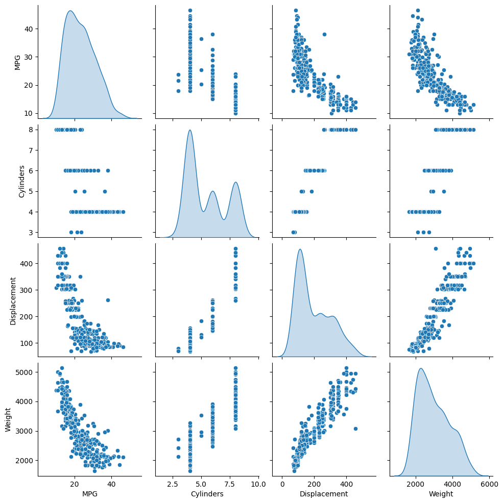

```python
#use seaborn to plot the joint distribution of the columns
sns.pairplot(train_ds[['MPG', 'Cylinders', 'Displacement', 'Weight']], diag_kind='kde')
```

```python
#Lets check the overall statistics of the dataset:
train_ds.describe().transpose()
```

|  | count | mean | std | min | 25% | 50% | 75% | max |
| --- | --- | --- | --- | --- | --- | --- | --- | --- |
| MPG | 314.0 | 23.310510 | 7.728652 | 10.0 | 17.00 | 22.0 | 28.95 | 46.6 |
| Cylinders | 314.0 | 5.477707 | 1.699788 | 3.0 | 4.00 | 4.0 | 8.00 | 8.0 |
| Displacement | 314.0 | 195.318471 | 104.331589 | 68.0 | 105.50 | 151.0 | 265.75 | 455.0 |
| Horsepower | 314.0 | 104.869427 | 38.096214 | 46.0 | 76.25 | 94.5 | 128.00 | 225.0 |
| Weight | 314.0 | 2990.251592 | 843.898596 | 1649.0 | 2256.50 | 2822.5 | 3608.00 | 5140.0 |
| Acceleration | 314.0 | 15.559236 | 2.789230 | 8.0 | 13.80 | 15.5 | 17.20 | 24.8 |
| Model Year | 314.0 | 75.898089 | 3.675642 | 70.0 | 73.00 | 76.0 | 79.00 | 82.0 |

```python
#Since that is the case, we split the target value from the other features. This target value is the value that
#you will train the model to predict
train_fs = train_ds.copy()
test_fs = test_ds.copy()

train_labels = train_fs.pop('MPG')
test_labels = test_fs.pop("MPG")
```

Practicing Normalization: The ranges of each feature are very different. Since this is the case, It is good we normalize these feautures. Normalization is the process of making all thefeatures of our dataset be contained in the same scales and ranges.

```python
#To add feature Normalization, we can use the following code:

#First, create your normalization layer
normalizer = tf.keras.layers.Normalization(axis = -1)

#Fit the state of the preprocessing layer to the data
normalizer.adapt(np.array(train_fs))

#Calculate the mean and variance and store them in the layer
print(normalizer.mean.numpy())
```

```
[[   5.478  195.318  104.869 2990.252   15.559   75.898    0.178    0.197
     0.624]]
```

Since the Target Value (MPG) depends on all the other variables, it is a multivariable linear regression problem. Lets start with a single variable linear regression to predict "MPG" from "Horsepower". Since we are using the keras module to train our model, we would first have to start by defining our model architecture. We will use a tf.keras.Sequential model, which represents a sequence of steps. There are two steps we would have to take in our single variable linear regression model:

- We will have to normalize the Horspower input features using the tf.keras.layers.Normalization preprocessing layer
- Apply a linear transformation to produce 1 output using a linear layer. For his, we can use the keras Dense layer

```python
#Whenthe normalization layer is called, it returns the input data, with each feature independently normalized

first = np.array(train_fs[:1])

with np.printoptions(precision=2, suppress=True):
  print('First example:', first)
  print()
  print('Normalized:', normalizer(first).numpy())
```

[output not shown]

```python
#Normalizing the horsepower feature

#Create a numpy array for the Horsepower feature
horsepower = np.array(train_fs['Horsepower'])

#instantiate the keras normalization layer
horsepower_normalizer = layers.Normalization(input_shape = [1,], axis = None)

#Fit its state to the horsepower data:
horsepower_normalizer.adapt(horsepower)
```

```python
#Building the Sequential Model
horsepower_model = tf.keras.Sequential([horsepower_normalizer,
                                       tf.keras.layers.Dense(units = 1)])


horsepower_model.summary()
```

```
Model: "sequential"
```

```
┏━━━━━━━━━━━━━━━━━━━━━━━━━━━━━━━━━━━━━━┳━━━━━━━━━━━━━━━━━━━━━━━━━━━━━┳━━━━━━━━━━━━━━━━━┓
┃ Layer (type)                         ┃ Output Shape                ┃         Param # ┃
┡━━━━━━━━━━━━━━━━━━━━━━━━━━━━━━━━━━━━━━╇━━━━━━━━━━━━━━━━━━━━━━━━━━━━━╇━━━━━━━━━━━━━━━━━┩
│ normalization_1 (Normalization)      │ (None, 1)                   │               3 │
├──────────────────────────────────────┼─────────────────────────────┼─────────────────┤
│ dense (Dense)                        │ (None, 1)                   │               2 │
└──────────────────────────────────────┴─────────────────────────────┴─────────────────┘
```

```
 Total params: 5 (24.00 B)
```

```
 Trainable params: 2 (8.00 B)
```

```
 Non-trainable params: 3 (16.00 B)
```

```python
#The horsepower model will predict the fuel efficiency based on the horsepower
```

```python
#Compiling the model
horsepower_model.compile(optimizer=tf.keras.optimizers.Adam(learning_rate=0.1), loss = 'mean_absolute_error')
```

```python
#fitting the Model: We  fit the model to train it
history = horsepower_model.fit(train_fs['Horsepower'], train_labels, epochs = 100, verbose = 0, validation_split=0.2)
```

We can visualize the models training progress by using the stats stored in the history object

```python
new_history = pd.DataFrame(history.history)
new_history['epoch'] = history.epoch
new_history.tail()
```

|  | loss | val_loss | epoch |
| --- | --- | --- | --- |
| 95 | 3.804118 | 4.184355 | 95 |
| 96 | 3.805307 | 4.190934 | 96 |
| 97 | 3.804336 | 4.207283 | 97 |
| 98 | 3.807969 | 4.189614 | 98 |
| 99 | 3.809113 | 4.209866 | 99 |

```python
def plot_loss(history):
  plt.plot(history.history['loss'], label='loss')
  plt.plot(history.history['val_loss'], label='val_loss')
  plt.ylim([0, 10])
  plt.xlabel('Epoch')
  plt.ylabel('Error [MPG]')
  plt.legend()
  plt.grid(True)
```

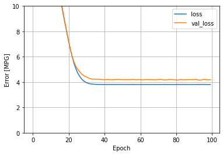

```python
plot_loss(history)
```

```python
#We will collect the results of the  tests
test_results = {}

test_results['horsepower_model'] = horsepower_model.evaluate(
    test_fs['Horsepower'],
    test_labels, verbose=0)
```

Because this is a single variable linear regression, it will be easier to view the model's prediction as a function of the input

```python
x = tf.linspace(0.0, 250, 251)
y = horsepower_model.predict(x)
```

```
8/8 ━━━━━━━━━━━━━━━━━━━━ 0s 5ms/step
```

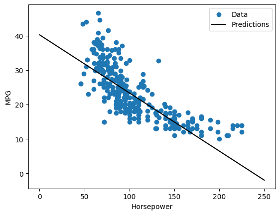

```python
plt.scatter(train_fs['Horsepower'], train_labels, label='Data')
  plt.plot(x, y, color='k', label='Predictions')
  plt.xlabel('Horsepower')
  plt.ylabel('MPG')
  plt.legend()
```